# Time Series Objects

This section will discuss methods to work with date and time in Python.

## Create Date Objects

- datetime can be used to create a date time object
- pd.TimeStamp() can also be used to create a date time object
- Timestamp() attributes and methods can be used to extract elements of date and time. E.g., .year, .month, .weekday()
- pd.date_range() is used to specify a sequence of dates
- pd.Period() is used to specify periodicity of time series. E.g., D, M, Y

### Using datetime

```python
import datetime as dt
date = dt.datetime(2010, 6, 17)
print('year', date.year)
print('month', date.month)
print('date', date.day)
```

```
year 2010
month 6
date 17
```

### Using pandas

```python
import pandas as pd
import matplotlib.pyplot as plt
date = pd.Timestamp(month = 6, year= 2010, day = 17)
print('year:', date.year)
print('month:', date.month)
print('month name:', date.month_name())
print('date:', date.day)
print('weekday name:', date.day_name())
```

```
year: 2010
month: 6
month name: June
date: 17
weekday name: Thursday
```

#### Sequence of Dates

```python
sequence_of_dates1 = pd.date_range(start = '2025-06-17', end = '2025-06-30', freq = '1D')
sequence_of_dates1
```

```
DatetimeIndex(['2025-06-17', '2025-06-18', '2025-06-19', '2025-06-20',
               '2025-06-21', '2025-06-22', '2025-06-23', '2025-06-24',
               '2025-06-25', '2025-06-26', '2025-06-27', '2025-06-28',
               '2025-06-29', '2025-06-30'],
              dtype='datetime64[ns]', freq='D')
```

```python
sequence_of_dates2 = pd.date_range(start = '2025-06-17', freq = '1D', periods = 14)
sequence_of_dates2
```

```
DatetimeIndex(['2025-06-17', '2025-06-18', '2025-06-19', '2025-06-20',
               '2025-06-21', '2025-06-22', '2025-06-23', '2025-06-24',
               '2025-06-25', '2025-06-26', '2025-06-27', '2025-06-28',
               '2025-06-29', '2025-06-30'],
              dtype='datetime64[ns]', freq='D')
```

```python
import numpy as np
np.random.seed(617)
sample_data = pd.DataFrame({'day': sequence_of_dates1.day,
                            'day_of_week': sequence_of_dates1.day_name()}, index = sequence_of_dates1)
sample_data.head()
```

|  | day | day_of_week |
| --- | --- | --- |
| 2025-06-17 | 17 | Tuesday |
| 2025-06-18 | 18 | Wednesday |
| 2025-06-19 | 19 | Thursday |
| 2025-06-20 | 20 | Friday |
| 2025-06-21 | 21 | Saturday |

## Parse Date Objects

To illustrate, we will read in nvda.csv. This dataset describes the daily price and volume for the stock of nVidia from 2010 to 2024.

```python
nvidia = pd.read_csv('nvda.csv',
                parse_dates=['Date'],
                date_format ='%Y-%m-%d')
nvidia.head()
```

|  | Date | Close_NVDA | High_NVDA | Low_NVDA | Open_NVDA | Volume_NVDA |
| --- | --- | --- | --- | --- | --- | --- |
| 0 | 2010-01-04 | 0.423854 | 0.426834 | 0.415143 | 0.424313 | 800204000 |
| 1 | 2010-01-05 | 0.430043 | 0.434628 | 0.422250 | 0.422250 | 728648000 |
| 2 | 2010-01-06 | 0.432794 | 0.433711 | 0.425688 | 0.429814 | 649168000 |
| 3 | 2010-01-07 | 0.424313 | 0.432336 | 0.421103 | 0.430502 | 547792000 |
| 4 | 2010-01-08 | 0.425230 | 0.428210 | 0.418353 | 0.420874 | 478168000 |

```python
nvidia = nvidia.set_index('Date')
nvidia.head()
```

| Date | Close_NVDA | High_NVDA | Low_NVDA | Open_NVDA | Volume_NVDA |
| --- | --- | --- | --- | --- | --- |
| 2010-01-04 | 0.423854 | 0.426834 | 0.415143 | 0.424313 | 800204000 |
| 2010-01-05 | 0.430043 | 0.434628 | 0.422250 | 0.422250 | 728648000 |
| 2010-01-06 | 0.432794 | 0.433711 | 0.425688 | 0.429814 | 649168000 |
| 2010-01-07 | 0.424313 | 0.432336 | 0.421103 | 0.430502 | 547792000 |
| 2010-01-08 | 0.425230 | 0.428210 | 0.418353 | 0.420874 | 478168000 |

pd.to_datetime() can automatically parse non-standard date formats. But, for large datasets this can be slow.

```python
random_dates =pd.Series(['Jan 1, 2025', 'Jan 2, 2025', 'Jan 5, 2025', 'Jan 9, 2025'])
pd.to_datetime(random_dates)
```

```
0   2025-01-01
1   2025-01-02
2   2025-01-05
3   2025-01-09
dtype: datetime64[ns]
```

```python
pd.to_datetime(random_dates,format='%b %d, %Y')
```

```
0   2025-01-01
1   2025-01-02
2   2025-01-05
3   2025-01-09
dtype: datetime64[ns]
```

## Transform Date and Time

### Slicing or Subsetting

A time series with a date index can be subset using square brackets.

- extract year range. df.loc[‘2023’:2024], df.loc[‘2023’:]
- extract month-year. df.loc[‘2020-03’:‘2020-04’]
- boolean masks. df[df.index>‘2024-12-25’]

All data for years 2023 and 2024

```python
nvidia.loc['2023':'2024'].head()
# nvidia.loc['2023':]
```

| Date | Close_NVDA | High_NVDA | Low_NVDA | Open_NVDA | Volume_NVDA |
| --- | --- | --- | --- | --- | --- |
| 2023-01-03 | 14.302286 | 14.982682 | 14.083481 | 14.837810 | 401277000 |
| 2023-01-04 | 14.735901 | 14.839809 | 14.228353 | 14.554063 | 431324000 |
| 2023-01-05 | 14.252331 | 14.551065 | 14.135434 | 14.478130 | 389168000 |
| 2023-01-06 | 14.845803 | 14.996669 | 14.021536 | 14.461145 | 405044000 |
| 2023-01-09 | 15.614121 | 16.041741 | 15.127553 | 15.270427 | 504231000 |

nVidia Stock between March and April 2020

```python
nvidia.loc['2020-03':'2020-04'].head()
```

| Date | Close_NVDA | High_NVDA | Low_NVDA | Open_NVDA | Volume_NVDA |
| --- | --- | --- | --- | --- | --- |
| 2020-03-02 | 6.884905 | 6.913797 | 6.500598 | 6.896612 | 890744000 |
| 2020-03-03 | 6.622391 | 7.000472 | 6.536962 | 6.940696 | 652792000 |
| 2020-03-04 | 7.086149 | 7.095613 | 6.655017 | 6.729737 | 597408000 |
| 2020-03-05 | 6.806698 | 7.053522 | 6.762115 | 6.886648 | 540328000 |
| 2020-03-06 | 6.626125 | 6.684655 | 6.425876 | 6.627121 | 515412000 |

nVidia Stock between March 10 and March 15, 2020

```python
nvidia.loc['2020-03-10':'2020-03-15']
```

| Date | Close_NVDA | High_NVDA | Low_NVDA | Open_NVDA | Volume_NVDA |
| --- | --- | --- | --- | --- | --- |
| 2020-03-10 | 6.502590 | 6.502590 | 6.126751 | 6.389514 | 580648000 |
| 2020-03-11 | 6.138706 | 6.391009 | 6.041571 | 6.362615 | 499964000 |
| 2020-03-12 | 5.387526 | 5.880924 | 5.374824 | 5.615420 | 816540000 |
| 2020-03-13 | 5.998482 | 6.002965 | 5.469717 | 5.740949 | 634836000 |

Data since 2024 Christmas.

```python
nvidia.loc[nvidia.index>'2024-12-25']
```

| Date | Close_NVDA | High_NVDA | Low_NVDA | Open_NVDA | Volume_NVDA |
| --- | --- | --- | --- | --- | --- |
| 2024-12-26 | 139.907410 | 140.827275 | 137.707768 | 139.677451 | 116205600 |
| 2024-12-27 | 136.987869 | 138.997554 | 134.688253 | 138.527629 | 170582600 |
| 2024-12-30 | 137.467804 | 140.247354 | 133.998363 | 134.808230 | 167734700 |

### Periodicity and Resampling

- Period converts a timestamp to a time span.
- Resampling aggregates data to a different frequency, like aggregating daily data to monthly.

```python
nvidia_2024 = nvidia.loc['2024':]
#nvidia_2024.to_period('Y')
nvidia_2024.to_period('M')
#nvidia_2024.to_period('W')
```

| Date | Close_NVDA | High_NVDA | Low_NVDA | Open_NVDA | Volume_NVDA |
| --- | --- | --- | --- | --- | --- |
| 2024-01 | 48.146572 | 49.273070 | 47.573829 | 49.222094 | 411254000 |
| 2024-01 | 47.547844 | 48.162568 | 47.298954 | 47.463882 | 320896000 |
| 2024-01 | 47.976650 | 48.478426 | 47.486867 | 47.745750 | 306535000 |
| 2024-01 | 49.075157 | 49.524958 | 48.284509 | 48.440441 | 415039000 |
| 2024-01 | 52.229759 | 52.251753 | 49.456995 | 49.489981 | 642510000 |
| ... | ... | ... | ... | ... | ... |
| 2024-12 | 139.647446 | 139.767421 | 135.098177 | 136.257994 | 176053500 |
| 2024-12 | 140.197372 | 141.877094 | 138.627618 | 139.977407 | 105157000 |
| 2024-12 | 139.907410 | 140.827275 | 137.707768 | 139.677451 | 116205600 |
| 2024-12 | 136.987869 | 138.997554 | 134.688253 | 138.527629 | 170582600 |
| 2024-12 | 137.467804 | 140.247354 | 133.998363 | 134.808230 | 167734700 |

251 rows × 5 columns

```python
nvidia_2024.resample('ME').mean()    # Average price for the month
```

| Date | Close_NVDA | High_NVDA | Low_NVDA | Open_NVDA | Volume_NVDA |
| --- | --- | --- | --- | --- | --- |
| 2024-01-31 | 56.234166 | 56.798106 | 55.172210 | 55.857286 | 4.622018e+08 |
| 2024-02-29 | 72.518180 | 73.656073 | 71.005153 | 72.397233 | 5.530678e+08 |
| 2024-03-31 | 89.406566 | 91.308353 | 87.324955 | 89.363441 | 6.074609e+08 |
| 2024-04-30 | 85.669805 | 87.692182 | 83.963076 | 86.057786 | 4.578334e+08 |
| 2024-05-31 | 96.181894 | 97.490191 | 94.198229 | 95.857160 | 4.384170e+08 |
| 2024-06-30 | 124.546660 | 126.876157 | 121.715276 | 124.503698 | 3.907461e+08 |
| 2024-07-31 | 121.874226 | 124.850104 | 119.493615 | 122.766216 | 2.911563e+08 |
| 2024-08-31 | 117.084831 | 119.943475 | 113.542769 | 116.787653 | 3.684258e+08 |
| 2024-09-30 | 115.025271 | 117.522590 | 112.584429 | 115.064258 | 3.135582e+08 |
| 2024-10-31 | 134.294721 | 136.255574 | 132.084796 | 134.357314 | 2.446921e+08 |
| 2024-11-30 | 142.479179 | 144.872130 | 140.216702 | 142.942574 | 2.248707e+08 |
| 2024-12-31 | 137.341865 | 139.617487 | 134.944280 | 137.387375 | 1.965098e+08 |

```python
nvidia_2024.resample('ME').mean().to_period('M')
```

| Date | Close_NVDA | High_NVDA | Low_NVDA | Open_NVDA | Volume_NVDA |
| --- | --- | --- | --- | --- | --- |
| 2024-01 | 56.234166 | 56.798106 | 55.172210 | 55.857286 | 4.622018e+08 |
| 2024-02 | 72.518180 | 73.656073 | 71.005153 | 72.397233 | 5.530678e+08 |
| 2024-03 | 89.406566 | 91.308353 | 87.324955 | 89.363441 | 6.074609e+08 |
| 2024-04 | 85.669805 | 87.692182 | 83.963076 | 86.057786 | 4.578334e+08 |
| 2024-05 | 96.181894 | 97.490191 | 94.198229 | 95.857160 | 4.384170e+08 |
| 2024-06 | 124.546660 | 126.876157 | 121.715276 | 124.503698 | 3.907461e+08 |
| 2024-07 | 121.874226 | 124.850104 | 119.493615 | 122.766216 | 2.911563e+08 |
| 2024-08 | 117.084831 | 119.943475 | 113.542769 | 116.787653 | 3.684258e+08 |
| 2024-09 | 115.025271 | 117.522590 | 112.584429 | 115.064258 | 3.135582e+08 |
| 2024-10 | 134.294721 | 136.255574 | 132.084796 | 134.357314 | 2.446921e+08 |
| 2024-11 | 142.479179 | 144.872130 | 140.216702 | 142.942574 | 2.248707e+08 |
| 2024-12 | 137.341865 | 139.617487 | 134.944280 | 137.387375 | 1.965098e+08 |

```python
nvidia_2024.resample('ME').first().to_period('M')   # Price on the first day of the month
```

| Date | Close_NVDA | High_NVDA | Low_NVDA | Open_NVDA | Volume_NVDA |
| --- | --- | --- | --- | --- | --- |
| 2024-01 | 48.146572 | 49.273070 | 47.573829 | 49.222094 | 411254000 |
| 2024-02 | 62.998966 | 63.162895 | 61.622580 | 62.072377 | 369146000 |
| 2024-03 | 82.242401 | 82.263396 | 79.399664 | 79.964416 | 479135000 |
| 2024-04 | 90.327042 | 92.188300 | 89.168506 | 90.263072 | 452441000 |
| 2024-05 | 83.007950 | 85.965772 | 81.222658 | 85.043143 | 559863000 |
| 2024-06 | 114.954239 | 114.954239 | 111.958430 | 113.575790 | 438392000 |
| 2024-07 | 124.260757 | 124.800580 | 118.792483 | 123.431018 | 284885500 |
| 2024-08 | 109.175514 | 120.122061 | 106.776271 | 117.492887 | 523462300 |
| 2024-09 | 107.965889 | 116.173295 | 107.256114 | 115.973361 | 477155100 |
| 2024-10 | 116.973053 | 122.411802 | 115.763333 | 121.741951 | 302094500 |
| 2024-11 | 135.368820 | 137.278384 | 134.539025 | 134.668984 | 207127800 |
| 2024-12 | 138.598083 | 140.417656 | 137.788272 | 138.798034 | 171682800 |

```python
nvidia_2024.resample('ME').last().to_period('M')   # Price on the last day of the month
```

| Date | Close_NVDA | High_NVDA | Low_NVDA | Open_NVDA | Volume_NVDA |
| --- | --- | --- | --- | --- | --- |
| 2024-01 | 61.499634 | 62.241304 | 60.673002 | 61.412671 | 453795000 |
| 2024-02 | 79.076813 | 79.954421 | 78.315151 | 79.058823 | 507289000 |
| 2024-03 | 90.320045 | 91.263670 | 89.157506 | 89.964184 | 435212000 |
| 2024-04 | 86.367622 | 88.783661 | 86.265666 | 87.205286 | 363709000 |
| 2024-05 | 109.589378 | 112.672151 | 106.897449 | 112.475223 | 613263000 |
| 2024-06 | 123.500984 | 127.669665 | 122.711233 | 124.540657 | 315516700 |
| 2024-07 | 116.983040 | 118.302623 | 110.844980 | 112.864346 | 473174200 |
| 2024-08 | 119.332306 | 121.711552 | 117.182983 | 119.492251 | 333751600 |
| 2024-09 | 121.412033 | 121.472017 | 118.122790 | 118.282749 | 226553700 |
| 2024-10 | 132.729431 | 137.578321 | 132.079587 | 137.568329 | 270039600 |
| 2024-11 | 138.218170 | 139.317923 | 136.018680 | 136.748507 | 141863200 |
| 2024-12 | 137.467804 | 140.247354 | 133.998363 | 134.808230 | 167734700 |

## Missing Values

- .ffill(): fills missing values by carrying forward the last known value
- .bfill(): fills missing values by using the next available value

To illustrate the use of the above let us add in the days in October 2024 when the market was closed. Lets see how many days the market was closed.

```python
nvidia_oct_2024 = nvidia.loc['2024-10',['Close_NVDA']]
nvidia_oct_2024 = nvidia_oct_2024.asfreq('D')
nvidia_oct_2024.isna().sum()
```

```
Close_NVDA    8
dtype: int64
```

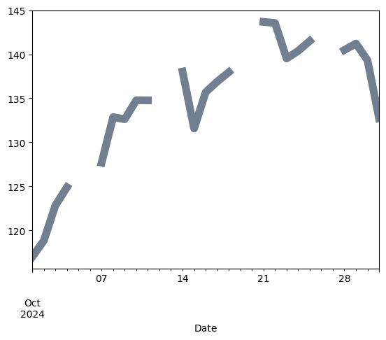

```python
nvidia_oct_2024.plot(legend = False, color = 'slategray', linewidth = 8)
plt.show()
```

```python
nvidia_oct_2024['ffill'] = nvidia_oct_2024.Close_NVDA.ffill()
nvidia_oct_2024['bfill'] = nvidia_oct_2024.Close_NVDA.bfill()
nvidia_oct_2024
```

| Date | Close_NVDA | ffill | bfill |
| --- | --- | --- | --- |
| 2024-10-01 | 116.973053 | 116.973053 | 116.973053 |
| 2024-10-02 | 118.822624 | 118.822624 | 118.822624 |
| 2024-10-03 | 122.821709 | 122.821709 | 122.821709 |
| 2024-10-04 | 124.891228 | 124.891228 | 124.891228 |
| 2024-10-05 | NaN | 124.891228 | 127.690598 |
| 2024-10-06 | NaN | 124.891228 | 127.690598 |
| 2024-10-07 | 127.690598 | 127.690598 | 127.690598 |
| 2024-10-08 | 132.859390 | 132.859390 | 132.859390 |
| 2024-10-09 | 132.619446 | 132.619446 | 132.619446 |
| 2024-10-10 | 134.778961 | 134.778961 | 134.778961 |
| 2024-10-11 | 134.768967 | 134.768967 | 134.768967 |
| 2024-10-12 | NaN | 134.768967 | 138.038223 |
| 2024-10-13 | NaN | 134.768967 | 138.038223 |
| 2024-10-14 | 138.038223 | 138.038223 | 138.038223 |
| 2024-10-15 | 131.569702 | 131.569702 | 131.569702 |
| 2024-10-16 | 135.688736 | 135.688736 | 135.688736 |
| 2024-10-17 | 136.898468 | 136.898468 | 136.898468 |
| 2024-10-18 | 137.968216 | 137.968216 | 137.968216 |
| 2024-10-19 | NaN | 137.968216 | 143.676910 |
| 2024-10-20 | NaN | 137.968216 | 143.676910 |
| 2024-10-21 | 143.676910 | 143.676910 | 143.676910 |
| 2024-10-22 | 143.556946 | 143.556946 | 143.556946 |
| 2024-10-23 | 139.527863 | 139.527863 | 139.527863 |
| 2024-10-24 | 140.377670 | 140.377670 | 140.377670 |
| 2024-10-25 | 141.507401 | 141.507401 | 141.507401 |
| 2024-10-26 | NaN | 141.507401 | 140.487656 |
| 2024-10-27 | NaN | 141.507401 | 140.487656 |
| 2024-10-28 | 140.487656 | 140.487656 | 140.487656 |
| 2024-10-29 | 141.217468 | 141.217468 | 141.217468 |
| 2024-10-30 | 139.307907 | 139.307907 | 139.307907 |
| 2024-10-31 | 132.729431 | 132.729431 | 132.729431 |

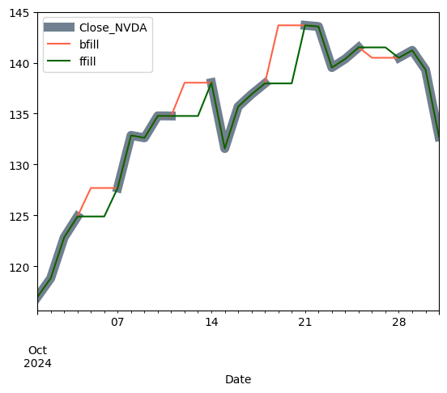

```python
nvidia_oct_2024['Close_NVDA'].plot(kind = 'line', linewidth=8, color ='slategray')
nvidia_oct_2024['bfill'].plot(color = 'tomato')
nvidia_oct_2024['ffill'].plot(color = 'darkgreen')
plt.legend()
plt.show()
```

## Time Series Transformations

Here are a few commonly used transformations with time-series data

- lag: Shifts the series backward to compare current values with past values.
- lead: Shifts the series forward to compare current values with future values.
- rolling: Apply a function (typically mean) over a sliding window.
- differencing: Change between consecutive observations.
- percent change: Percent change between consecutive observations. With stock price data, this would be called return.

```python
nvidia = pd.read_csv('nvda.csv',
                     usecols=['Close_NVDA','Date'],
                     index_col=['Date'],
                     parse_dates=['Date'],
                     date_format ='%Y-%m-%d')
nvidia['lag'] = nvidia.Close_NVDA.shift(periods = 1) # lag, push ahead
nvidia['lead'] = nvidia.Close_NVDA.shift(periods = -1) # lead, push back
nvidia['moving_average'] = nvidia.Close_NVDA.rolling(window = 50).mean()  # 50-day MA
nvidia['diff'] = nvidia.Close_NVDA.diff()
nvidia['pct_change'] = nvidia.Close_NVDA.pct_change()
nvidia
```

| Date | Close_NVDA | lag | lead | moving_average | diff | pct_change |
| --- | --- | --- | --- | --- | --- | --- |
| 2010-01-04 | 0.423854 | NaN | 0.430043 | NaN | NaN | NaN |
| 2010-01-05 | 0.430043 | 0.423854 | 0.432794 | NaN | 0.006189 | 0.014602 |
| 2010-01-06 | 0.432794 | 0.430043 | 0.424313 | NaN | 0.002751 | 0.006397 |
| 2010-01-07 | 0.424313 | 0.432794 | 0.425230 | NaN | -0.008482 | -0.019597 |
| 2010-01-08 | 0.425230 | 0.424313 | 0.419270 | NaN | 0.000917 | 0.002161 |
| ... | ... | ... | ... | ... | ... | ... |
| 2024-12-23 | 139.647446 | 134.678253 | 140.197372 | 139.688260 | 4.969193 | 0.036897 |
| 2024-12-24 | 140.197372 | 139.647446 | 139.907410 | 139.731443 | 0.549927 | 0.003938 |
| 2024-12-26 | 139.907410 | 140.197372 | 136.987869 | 139.898197 | -0.289963 | -0.002068 |
| 2024-12-27 | 136.987869 | 139.907410 | 137.467804 | 139.924180 | -2.919540 | -0.020868 |
| 2024-12-30 | 137.467804 | 136.987869 | NaN | 139.935567 | 0.479935 | 0.003503 |

3773 rows × 6 columns

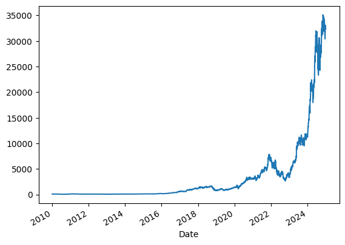

```python
nvidia.Close_NVDA.diff()                                  # difference from prior day, period = 1
nvidia.Close_NVDA.pct_change().mul(100)                   # percent change from previous day, period = 1
nvidia.Close_NVDA.div(nvidia.Close_NVDA.iloc[0]).mul(100).plot() # compare to start of the series
plt.show()
```

## Summary

In this note we examined how to work with date and time in Python.

This file was generated using Python 3.13.5 on Windows 10 with the following libraries: matplotlib 3.10.3, numpy 2.3.1, pandas 2.3.0